# P2: Analyzing the NYC Subway Dataset

## Overview

This project consists of two parts. In Part 1 of the project, you should have completed the questions in Problem Sets 2, 3, and 4 in the Introduction to Data Science course.

This document addresses part 2 of the project. Please use this document as a template and answer the following questions to explain your reasoning and conclusion behind your work in the problem sets. You will attach a document with your answers to these questions as part of your final project submission.

### Section 0. References

http://docs.scipy.org/doc/scipy/reference/generated/scipy.stats.mannwhitneyu.html

https://en.wikipedia.org/wiki/Mann%E2%80%93Whitney_U_test#Assumptions_and_formal_statement_of_hypotheses

http://stackoverflow.com/questions/6986986/bin-size-in-matplotlib-histogram

https://discussions.udacity.com/t/ggplot-has-blank-space-on-right/37448

```python
%matplotlib inline
import numpy as np
import scipy
import scipy.stats
import pandas
import matplotlib.pyplot as plt
import statsmodels.api as sm
from datetime import datetime
from ggplot import *

turnstile_weather = pandas.read_csv("./turnstile_data_master_with_weather.csv")
```

### Section 1. Statistical Test

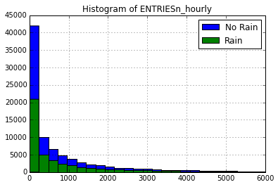

```python
plt.figure()
turnstile_weather['ENTRIESn_hourly'][turnstile_weather.rain == 0].hist(bins=25, range=(0,6000), label="No Rain")
turnstile_weather['ENTRIESn_hourly'][turnstile_weather.rain == 1].hist(bins=25, range=(0,6000), label="Rain")
plt.title("Histogram of ENTRIESn_hourly")
plt.legend()
```

```python
with_rain = turnstile_weather['ENTRIESn_hourly'][turnstile_weather.rain == 1]
without_rain = turnstile_weather['ENTRIESn_hourly'][turnstile_weather.rain == 0]
with_rain_mean = np.mean(with_rain)
without_rain_mean = np.mean(without_rain)
mwu = scipy.stats.mannwhitneyu(with_rain, without_rain)
U = mwu[0]
p = mwu[1]*2
with_rain_mean, without_rain_mean, U, p
```

```
(1105.4463767458733, 1090.278780151855, 1924409167.0, 0.049999825586979442)
```

#### 1.1 Which statistical test did you use to analyze the NYC subway data? Did you use a one-tail or a two-tail P value? What is the null hypothesis? What is your p-critical value?

I used a Mann-Whitney U-test with two-tailed P-value. The null hypothesis was that the distribution of hourly entries into subway stations in NYC were the same between rainy and non-rain conditions. The alternative hypothesis was that the probability of an hourly entry without rain being greater than an hourly entry with rain was not equal to the probability of an hourly entry with rain being greather than an hourly entry with without rain. We used a two-tailed p-value because we do not specify if the difference during rain is greater than or less than the entries during non-rain. A critical value of 0.05 was used.

#### 1.2 Why is this statistical test applicable to the dataset? In particular, consider the assumptions that the test is making about the distribution of ridership in the two samples.

We are using Mann-Whitney U-test because the data is non-normal (see histogram above).

#### 1.3 What results did you get from this statistical test? These should include the following numerical values: p-values, as well as the means for each of the two samples under test.

Mean hourly entries with rain: 1105

Mean hourly entries without rain: 1090

U-statistic: 1924409167

p-value: 0.0499998

#### 1.4 What is the significance and interpretation of these results?

We reject the null hypothesis since the p-value is under 0.05 and conclude that the distribution of hourly entries to NYC subway stations are not the same between rain and no-rain conditions. The mean entries are higher for rain suggesting that there is an increased in subway ridership when it is rainning.

### Section 2. Linear Regression

```python
def linear_regression(features, values):

    features = sm.add_constant(features)
    model = sm.OLS(values, features)
    results = model.fit()
    intercept = results.params[0]
    params = results.params[1:]

    return intercept, params

def predictions(dataframe):
    features = dataframe[['precipi', 'Hour', 'meandewpti']]
    dummy_units = pandas.get_dummies(dataframe['UNIT'], prefix='unit')
    features = features.join(dummy_units)

    # Values
    values = dataframe['ENTRIESn_hourly']

    # Perform linear regression
    intercept, params = linear_regression(features, values)

    predictions = intercept + np.dot(features, params)
    return intercept, params, predictions

[model_intercept, model_param, model_predictions] = predictions(turnstile_weather)
[model_intercept, model_param, model_predictions]
```

```
[1067.8853402933114, precipi         71.007407
 Hour            67.404459
 meandewpti      -4.305779
 unit_R001     2429.643537
 unit_R002     -633.258716
 unit_R003    -1331.370915
 unit_R004    -1005.772236
 unit_R005    -1019.721870
 unit_R006     -948.229638
 unit_R007    -1167.834450
 unit_R008    -1134.788593
 unit_R009    -1206.303993
 unit_R010     3030.572162
 unit_R011     6515.154760
 unit_R012     5952.924292
 unit_R013      964.613397
 unit_R014     2486.856108
 unit_R015      625.558242
 unit_R016     -566.458675
 unit_R017     2709.515977
 unit_R018     4422.736911
 unit_R019     1376.875155
 unit_R020     4982.433186
 unit_R021     2947.088351
 unit_R022     7104.429397
 unit_R023     5027.022404
 unit_R024     1506.794471
 unit_R025     3513.349584
 unit_R027     1430.501172
 unit_R028      768.809505
                  ...
 unit_R450    -1031.322375
 unit_R451     -605.484763
 unit_R452     4214.154051
 unit_R453      314.802860
 unit_R454    -1342.371685
 unit_R455    -1396.035416
 unit_R456    -1268.747590
 unit_R459    -1419.432810
 unit_R460       15.771944
```

[output cut: 8 more lines]

```
 unit_R540    -1368.620878
 unit_R541    -1475.370359
 unit_R542    -1495.262626
 unit_R543    -1532.082922
 unit_R544    -1545.657044
 unit_R545    -1495.933645
 unit_R546    -1357.000541
 unit_R547    -1463.083726
 unit_R548    -1428.608026
 unit_R549    -1569.125713
 unit_R550    -1530.927278
 unit_R551    -1504.352286
 unit_R552    -1439.311437
 dtype: float64, array([ 3397.00794908,  3666.62578583,  3936.24362259, ...,   906.67562972,
          906.67562972,   906.67562972])]
```

```python
r_data = turnstile_weather['ENTRIESn_hourly']
r_squared = 1 - np.sum((r_data-model_predictions)**2)/sum((r_data-np.mean(r_data))**2)
r_squared
```

```
0.45795994209043134
```

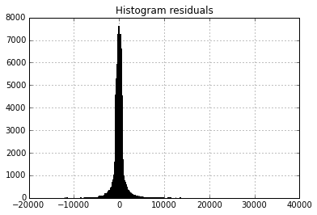

```python
plt.figure()
resid = turnstile_weather['ENTRIESn_hourly'] - model_predictions
(resid).hist(bins = range(int(min(resid)), int(max(resid)) + 100, 100))
plt.title('Histogram residuals')
```

#### 2.1 What approach did you use to compute the coefficients theta and produce prediction for ENTRIESn_hourly in your regression model:

a. OLS using Statsmodels

#### 2.2 What features (input variables) did you use in your model? Did you use any dummy variables as part of your features?

I used precipitation, hour, mean dew point station. Station was a dummy variable.

#### 2.3 Why did you select these features in your model? We are looking for specific reasons that lead you to believe that

I used intuition for this model. I thought including station information was very important since different stations have vastly different number of riders. I included precipitation instead of rain because it is a quantitative matric (rain is boolean).

#### 2.4 What are the parameters (also known as "coefficients" or "weights") of the non-dummy features in your linear regression model?

` precipi 71.007407 Hour 67.404459 meandewpti -4.305779 `

#### 2.5 What is your model’s R^2 (coefficients of determination) value?

0.458

#### 2.6 What does this R^2 value mean for the goodness of fit for your regression model? Do you think this linear model to predict ridership is appropriate for this dataset, given this R^2 value?

45.8% of the variation of hourly entries of NYC subway stations is explained by the selected features. The residuals are normally distributed around 0 which is a good sign, however, the range is quite large especially compared to the mean hourly entries is only around 1000.

### Section 3. Visualization

Please include two visualizations that show the relationships between two or more variables in the NYC subway data.

Remember to add appropriate titles and axes labels to your plots. Also, please add a short description below each figure commenting on the key insights depicted in the figure.

#### 3.1 One visualization should contain two histograms: one of ENTRIESn_hourly for rainy days and one of ENTRIESn_hourly for non-rainy days.

- You can combine the two histograms in a single plot or you can use two separate plots.
- If you decide to use to two separate plots for the two histograms, please ensure that the x-axis limits for both of the plots are identical. It is much easier to compare the two in that case.
- For the histograms, you should have intervals representing the volume of ridership (value of ENTRIESn_hourly) on the x-axis and the frequency of occurrence on the y-axis. For example, each interval (along the x-axis), the height of the bar for this interval will represent the number of records (rows in our data) that have ENTRIESn_hourly that falls in this interval.
- Remember to increase the number of bins in the histogram (by having larger number of bars). The default bin width is not sufficient to capture the variability in the two samples.

```python
[max(turnstile_weather['ENTRIESn_hourly']), min(turnstile_weather['ENTRIESn_hourly'])]
```

```
[51839.0, 0.0]
```

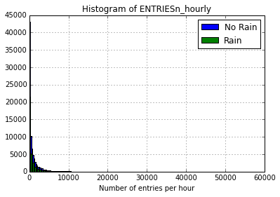

```python
plt.figure()
turnstile_weather['ENTRIESn_hourly'][turnstile_weather.rain == 0].hist(bins=200, range=(0,51839), label="No Rain")
turnstile_weather['ENTRIESn_hourly'][turnstile_weather.rain == 1].hist(bins=200, range=(0,51839), label="Rain")
plt.title("Histogram of ENTRIESn_hourly")
plt.xlabel('Number of entries per hour')
plt.legend()
```

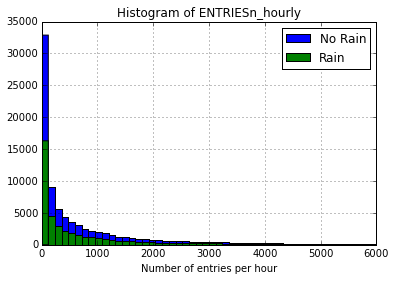

```python
plt.figure()
turnstile_weather['ENTRIESn_hourly'][turnstile_weather.rain == 0].hist(bins=50, range=(0,6000), label="No Rain")
turnstile_weather['ENTRIESn_hourly'][turnstile_weather.rain == 1].hist(bins=50, range=(0,6000), label="Rain")
plt.title("Histogram of ENTRIESn_hourly")
plt.xlabel('Number of entries per hour')
plt.legend()
```

The histograms above show both the full range and a zoomed in version. What this plot shows is that there is a very long tail (few stations with high number of entries per hour).

#### 3.2 One visualization can be more freeform. You should feel free to implement something that we discussed in class (e.g., scatter plots, line plots) or attempt to implement something more advanced if you'd like. Some suggestions are:

- Ridership by time-of-day
- Ridership by day-of-week

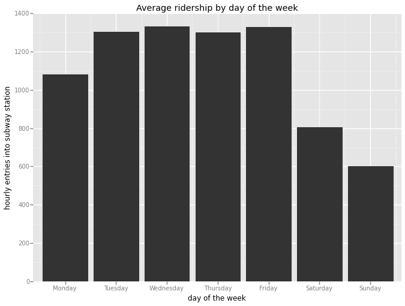

```python
dotw = turnstile_weather.DATEn.apply(lambda x: datetime.strptime(x, "%Y-%m-%d").strftime("%A"))
turnstile_weather = turnstile_weather.assign(dotw=dotw) # aadd new column

entries_by_day = turnstile_weather[['dotw', 'ENTRIESn_hourly']].groupby('dotw')
entries_by_day = entries_by_day.aggregate(np.mean)
entries_by_day = entries_by_day.reindex(["Monday", "Tuesday", "Wednesday", "Thursday", "Friday", "Saturday", "Sunday"])
entries_by_day = entries_by_day.reset_index() #  ggplot won't plot index

ggplot(entries_by_day, aes(x='dotw', y='ENTRIESn_hourly')) + \
    ylab('hourly entries into subway station') + \
    xlab('day of the week') + \
    geom_bar(stat='identity') + \
    ggtitle('Average ridership by day of the week')
```

### Section 4. Conclusion

Please address the following questions in detail. Your answers should be 1-2 paragraphs long.

```python
def predictions(dataframe):
    features = dataframe[['rain', 'meandewpti']]
    dummy_units = pandas.get_dummies(dataframe['Hour'], prefix='h')
    features = features.join(dummy_units)
    dummy_units = pandas.get_dummies(dataframe['UNIT'], prefix='unit')
    features = features.join(dummy_units)

    # Values
    values = dataframe['ENTRIESn_hourly']

    # Perform linear regression
    intercept, params = linear_regression(features, values)

    predictions = intercept + np.dot(features, params)
    return intercept, params, predictions

[model_intercept, model_param, model_predictions] = predictions(turnstile_weather)
[model_intercept, model_param, model_predictions]
```

```
[1596.5178733039058, rain            60.392022
 meandewpti      -4.926595
 h_0             18.265742
 h_1           -359.448051
 h_2           -166.657472
 h_3            -78.382882
 h_4           -881.816190
 h_5           -816.798761
 h_6           -338.415516
 h_7           -406.409527
 h_8           -627.036266
 h_9            284.460558
 h_10           -10.065333
 h_11           -70.210222
 h_12          1257.651383
 h_13           116.499743
 h_14          -300.168657
 h_15           -55.674598
 h_16           704.042957
 h_17           555.877060
 h_18           293.852880
 h_19           215.598992
 h_20          1499.867931
 h_21           637.452330
 h_22           134.130650
 h_23           -10.098876
 unit_R001     2612.470456
 unit_R002     -456.099929
 unit_R003    -1536.593906
 unit_R004    -1208.208271
                  ...
 unit_R450     -862.342235
 unit_R451     -433.543590
 unit_R452     4384.281338
 unit_R453      119.027157
 unit_R454    -1567.681636
 unit_R455    -1610.916385
 unit_R456    -1394.012703
 unit_R459    -1601.807693
 unit_R460      176.083468
```

[output cut: 8 more lines]

```
 unit_R540    -1162.496372
 unit_R541    -1266.784148
 unit_R542    -1288.473608
 unit_R543    -1321.953157
 unit_R544    -1330.319331
 unit_R545    -1285.371548
 unit_R546    -1143.864764
 unit_R547    -1264.359816
 unit_R548    -1211.555760
 unit_R549    -1352.783952
 unit_R550    -1323.470559
 unit_R551    -1301.808981
 unit_R552    -1219.294721
 dtype: float64, array([ 3657.40306854,  3200.05235856,  4301.31167799, ...,    92.50782966,
           92.50782966,    92.50782966])]
```

```python
r_data = turnstile_weather['ENTRIESn_hourly']
r_squared = 1 - np.sum((r_data-model_predictions)**2)/sum((r_data-np.mean(r_data))**2)
r_squared
```

```
0.50126695754768291
```

#### 4.1 From your analysis and interpretation of the data, do more people ride the NYC subway when it is raining or when it is not raining?

Yes, more people ride the subway when it is rainning.

#### 4.2 What analyses lead you to this conclusion? You should use results from both your statistical tests and your linear regression to support your analysis.

The Mann-Whitney U-test performed on hourly entries into subway stations in rainning versus non-raining conditions showed that the these two conditions did not have the same distribution. Additionally, the mean of the entries per hour with rain is higher than entries per hour without rain and rain coefficient in our model above has a large positive value (60) indicating that rain is associated with larger number of entries per hour.

### Section 5. Reflection

Please address the following questions in detail. Your answers should be 1-2 paragraphs long.

#### 5.1 Please discuss potential shortcomings of the methods of your analysis, including: Dataset, Analysis, such as the linear regression model or statistical test.

Dataset provided does not account for holidays (such as thanksgiving) where ridership might be lower or events (such as new years or parades) where ridership might be higher. These events could be included into the model as dummy variables to help improve accuracy of the linear model. Snow could also be a quantitative factor that could be added into the model. Some of the factors we are modeling might have non-linear relationships that the linear regression model cannot capture well.

#### 5.2 (Optional) Do you have any other insight about the dataset that you would like to share with us?

Not really any other insights but it kind of bugs me that the R^2 value is so low.